# FinalDraftv4.1 (1)

### Project Overview:

Analysis of COVID-19 Vaccination Trends

- The purpose of this project is to understand vaccination trends and provide actionable insights
- Tools used: Python libraries like Pandas, Matplotlib, and Seaborn for data analysis and visualization

```python
import pandas as pd
import numpy as np
import matplotlib.pyplot as plt
import seaborn as sns
```

### Tools and Libraries:

- Pandas: for data manipulation and analysis.
- Matplotlib/Seabord: for creating insightful visualizations.
- NumPy: for handling numerical operations efficiently.

### Dataset Previews

- Dataset 1: CMS vaccination data focusing on "up-to-date" and "not up-to-date" indicators (CMS dataset).
- Dataset 2: Weekly vaccination trends by demographics and geographic levels (CDC dataset).

```python
#data from CMS regarding up-to-date by State
df = pd.read_csv('NH_CovidVaxAverages_20241110.csv')
df.head()
```

|  | State | Percent of residents who are up-to-date on their vaccines | Percent of staff who are up-to-date on their vaccines | Date vaccination data last updated |
| --- | --- | --- | --- | --- |
| 0 | US | 30.4 | 6.4 | 11/10/2024 |
| 1 | AK | 53.9 | 11.8 | 11/10/2024 |
| 2 | AL | 22.6 | 2.7 | 11/10/2024 |
| 3 | AR | 17.3 | 2.6 | 11/10/2024 |
| 4 | AZ | 23.3 | 5.4 | 11/10/2024 |

### Vaccination Rates by State & Territory:

- Bar chart visualizing vaccination rates among residents by state.
- Key insight: Top performers are VT and AK while lowest performers are TX and AR.

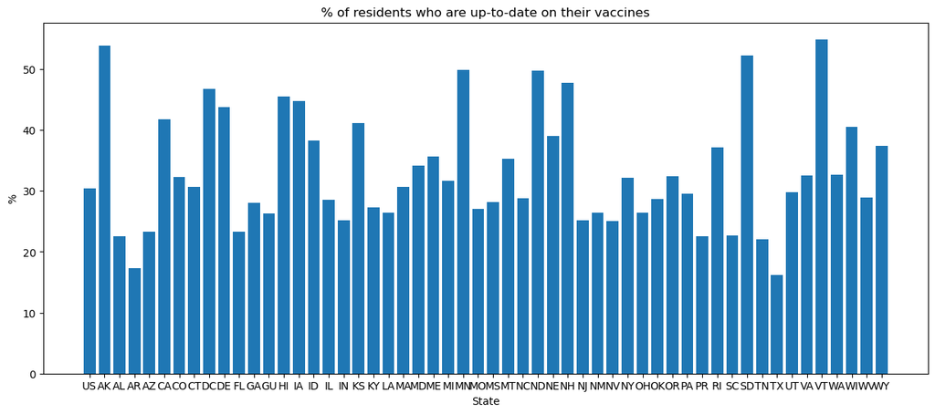

```python
plt.figure(figsize=(15,6))
plt.bar(x = df['State'],

       height = df['Percent of residents who are up-to-date on their vaccines']
       )
plt.title("% of residents who are up-to-date on their vaccines")
plt.xlabel('State')
plt.ylabel('%')
plt.show()
```

### Residents vs. Staff Vaccination Comparison

Comparison of rates for residents and staff. Used a stacked bar chart to emphasize disparities.

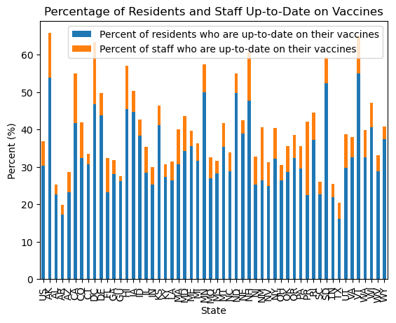

```python
plt.figure(figsize=(125,36))

df.set_index('State')[['Percent of residents who are up-to-date on their vaccines',
                              'Percent of staff who are up-to-date on their vaccines']].plot(kind='bar', stacked=True)

plt.xlabel('State')
plt.ylabel('Percent (%)')
plt.title('Percentage of Residents and Staff Up-to-Date on Vaccines')
plt.show()
```

```python
sorted_df = df.sort_values(by='Percent of staff who are up-to-date on their vaccines', ascending=False)
```

```python
df['Percent_total'] = df['Percent of residents who are up-to-date on their vaccines'] + df['Percent of staff who are up-to-date on their vaccines']
df.head()
```

|  | State | Percent of residents who are up-to-date on their vaccines | Percent of staff who are up-to-date on their vaccines | Date vaccination data last updated | Percent_total |
| --- | --- | --- | --- | --- | --- |
| 0 | US | 30.4 | 6.4 | 11/10/2024 | 36.8 |
| 1 | AK | 53.9 | 11.8 | 11/10/2024 | 65.7 |
| 2 | AL | 22.6 | 2.7 | 11/10/2024 | 25.3 |
| 3 | AR | 17.3 | 2.6 | 11/10/2024 | 19.9 |
| 4 | AZ | 23.3 | 5.4 | 11/10/2024 | 28.7 |

```python
sorted_df = df.sort_values(by='Percent_total', ascending=False)
sorted_df.head()
```

|  | State | Percent of residents who are up-to-date on their vaccines | Percent of staff who are up-to-date on their vaccines | Date vaccination data last updated | Percent_total |
| --- | --- | --- | --- | --- | --- |
| 1 | AK | 53.9 | 11.8 | 11/10/2024 | 65.7 |
| 49 | VT | 54.9 | 10.2 | 11/10/2024 | 65.1 |
| 8 | DC | 46.7 | 16.6 | 11/10/2024 | 63.3 |
| 32 | NH | 47.7 | 12.9 | 11/10/2024 | 60.6 |
| 44 | SD | 52.3 | 7.0 | 11/10/2024 | 59.3 |

### Top and Bottom 10 States & Territories:

Here we can see the highest and lowest performers regarding vaccination rates.

```python
df_top10 = sorted_df.head(10)
```

```python
df_last10 = sorted_df.tail(10)
```

```python
df_combined = pd.concat([df_top10, df_last10])
```

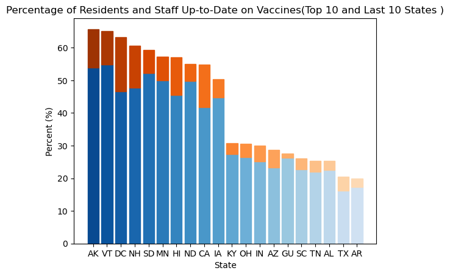

```python
faded_colors_residents = plt.cm.Blues(np.linspace(0.9, 0.2, len(df_combined)))
faded_colors_staff = plt.cm.Oranges(np.linspace(0.9, 0.2, len(df_combined)))

bars_residents=plt.bar(x=df_combined['State'],
            height=df_combined['Percent of residents who are up-to-date on their vaccines'],
            label='Residents', color=faded_colors_residents)

bars_staff=plt.bar(x=df_combined['State'],
            height=df_combined['Percent of staff who are up-to-date on their vaccines'],
            bottom=df_combined['Percent of residents who are up-to-date on their vaccines'],
            label='Staff', color=faded_colors_staff)

for bar, color in zip(bars_residents, faded_colors_residents):
    bar.set_color(color)

for bar, color in zip(bars_staff, faded_colors_staff):
    bar.set_color(color)

plt.xlabel('State')
plt.ylabel('Percent (%)')
plt.title('Percentage of Residents and Staff Up-to-Date on Vaccines(Top 10 and Last 10 States )')
plt.show()
```

### Weekly Vaccination Trends

Below you will see trends regarding "up-to-date" and "not up-to-date" rates over time. We used a line chart that tracks progress between September of 2023 to November of 2024.

```python
df2 = pd.read_csv('indic_yesnocsv.csv')
df2
```

|  | indicator_label | indicator_category_label | Month_Week | Week_ending | Estimate | CI_Half_width_95pct | Unweighted Sample Size | COVID_season |
| --- | --- | --- | --- | --- | --- | --- | --- | --- |
| 0 | Up-to-date | Yes | October Week 1 | 9/30/23 0:00 | 3.0 | 0.4893 | 612086 | 2023-2024 |
| 1 | 4-level vaccination and intent | No | October Week 1 | 9/30/23 0:00 | 37.1 | 1.6836 | 19614 | 2023-2024 |
| 2 | Up-to-date | Yes | October Week 2 | 10/7/23 0:00 | 4.8 | 0.3402 | 612086 | 2023-2024 |
| 3 | 4-level vaccination and intent | No | October Week 2 | 10/7/23 0:00 | 36.5 | 2.0927 | 13497 | 2023-2024 |
| 4 | Up-to-date | Yes | October Week 3 | 10/14/23 0:00 | 6.8 | 0.3979 | 612086 | 2023-2024 |
| ... | ... | ... | ... | ... | ... | ... | ... | ... |
| 111 | Up-to-date | Yes | November Week 1 | 11/2/24 0:00 | 17.3 | 0.8352 | 123528 | 2024-2025 |
| 112 | 4-level vaccination and intent | No | November Week 2 | 11/9/24 0:00 | 41.4 | 2.2759 | 9439 | 2024-2025 |
| 113 | Up-to-date | Yes | November Week 2 | 11/9/24 0:00 | 18.3 | 0.8960 | 123528 | 2024-2025 |
| 114 | 4-level vaccination and intent | No | November Week 3 | 11/16/24 0:00 | 44.1 | 2.0995 | 11488 | 2024-2025 |
| 115 | Up-to-date | Yes | November Week 3 | 11/16/24 0:00 | 18.9 | 0.9226 | 123528 | 2024-2025 |

116 rows × 8 columns

```python
df2_vac = df2.loc[df2['indicator_category_label'].isin(['Yes'])]
df2_vac_sub = df2_vac[["Week_ending", "Estimate"]]
```

```python
df2_nvac = df2.loc[df2['indicator_category_label'].isin(['No'])]
df2_nvac_sub = df2_nvac[["Week_ending", "Estimate"]]
```

```python
print(df2_nvac_sub['Week_ending'].head())
```

```
1     9/30/23 0:00
3     10/7/23 0:00
5    10/14/23 0:00
7    10/21/23 0:00
9    10/28/23 0:00
Name: Week_ending, dtype: object
```

```python
df2_nvac_sub.loc[:, 'Week_ending'] = pd.to_datetime(df2_nvac_sub['Week_ending'])
```

```python
df2_nvac_sub.loc[:, 'Week_ending'] = pd.to_datetime(df2_nvac_sub['Week_ending'], format='%Y-%m-%d')
```

```python
df2_nvac_sub = df2_nvac_sub.sort_values(by='Week_ending', ascending=True)
```

```python
df2_vac_sub.loc[:, 'Week_ending'] = pd.to_datetime(df2_vac_sub['Week_ending'])
```

```python
df2_vac_sub.loc[:, 'Week_ending'] = pd.to_datetime(df2_vac_sub['Week_ending'], format='%Y-%m-%d')
```

```python
df2_vac_sub = df2_vac_sub.sort_values(by='Week_ending', ascending=True)
```

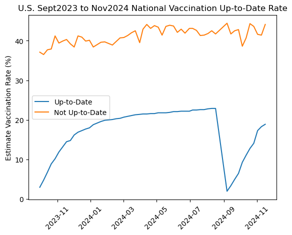

```python
plt.plot(df2_vac_sub['Week_ending'], df2_vac_sub['Estimate'])
plt.plot(df2_nvac_sub['Week_ending'], df2_nvac_sub['Estimate'])
plt.xticks(rotation=45)
plt.title("U.S. Sept2023 to Nov2024 National Vaccination Up-to-Date Rate")
plt.ylabel('Estimate Vaccination Rate (%)')
plt.legend(["Up-to-Date", 'Not Up-to-Date'])
plt.show()
```

### Vaccination Rates by Demographics

- Focus on Race/Ethnicity and other demographic information regarding COVID-19 vaccinations.

```python
import pandas as pd
import matplotlib.pyplot as plt
import seaborn as sns
```

```python
# Replace the file path with your local path if not in the same directory.
file_path = 'Weekly_Cumulative_COVID-19_Vaccination_Coverage_and_Intent__Overall__by_Selected_Demographics_and_Jurisdiction__Among_Adults_18_Years_and_Older_20241204.csv'
data = pd.read_csv(file_path)

# Preview the dataset
print(data.head())
```

```
  Vaccine Geographic Level Geographic Name Demographic Level  \
0   COVID         National        National    Race/Ethnicity
1   COVID         National        National        Urbanicity
2   COVID         National        National    Race/Ethnicity
3   COVID         National        National    Race/Ethnicity
4   COVID           Region        Region 7           Overall

                                    Demographic Name  \
0  Multiple Race/Other (Excludes Asian, AIAN, PI/...
1                                    Rural (Non-MSA)
2                                Asian, Non-Hispanic
3                                White, Non-Hispanic
4                                          18+ years

                  indicator_label                   indicator_category_label  \
```

[output cut: 26 more lines]

```python
# Filter data for Race/Ethnicity demographics
race_ethnicity_data = data[data['Demographic Level'] == 'Race/Ethnicity']

# Check the filtered data
print(race_ethnicity_data.head())
```

```
   Vaccine Geographic Level Geographic Name Demographic Level  \
0    COVID         National        National    Race/Ethnicity
2    COVID         National        National    Race/Ethnicity
3    COVID         National        National    Race/Ethnicity
7    COVID         National        National    Race/Ethnicity
50   COVID         National        National    Race/Ethnicity

                                     Demographic Name  \
0   Multiple Race/Other (Excludes Asian, AIAN, PI/...
2                                 Asian, Non-Hispanic
3                                 White, Non-Hispanic
7                                 Other, Non-Hispanic
50        American Indian/Alaska Native, Non-Hispanic

                   indicator_label                   indicator_category_label  \
```

[output cut: 26 more lines]

```python
# Group by demographic name and calculate the average vaccination rate
summary_race_ethnicity = race_ethnicity_data.groupby('Demographic Name')['Estimate'].mean().reset_index()

# Rename columns for better clarity
summary_race_ethnicity.columns = ['Race/Ethnicity', 'Average Vaccination Rate']

# Display the summarized data
print(summary_race_ethnicity)
```

```
                                      Race/Ethnicity  Average Vaccination Rate
0        American Indian/Alaska Native, Non-Hispanic                 22.156949
1                                Asian, Non-Hispanic                 23.302373
2                                Black, Non-Hispanic                 23.031525
3                                           Hispanic                 22.298644
4  Multiple Race/Other (Excludes Asian, AIAN, PI/...                 22.560678
5                                Other, Non-Hispanic                 22.914576
6     Pacific Islander/Native Hawaiian, Non-Hispanic                 22.337456
7                                White, Non-Hispanic                 23.969492
```

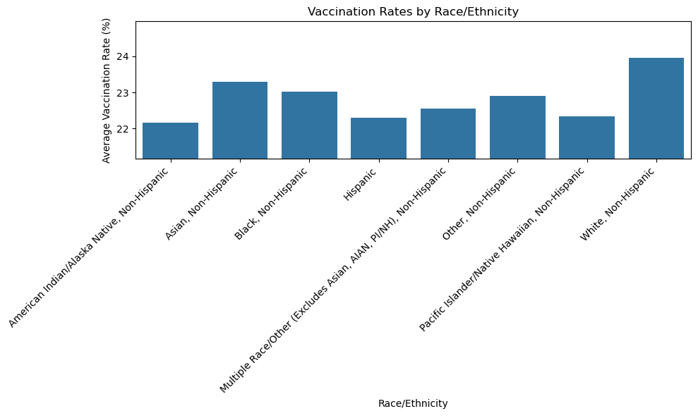

```python
# Bar chart with adjusted y-axis
plt.figure(figsize=(10, 6))
sns.barplot(x='Race/Ethnicity', y='Average Vaccination Rate', data=summary_race_ethnicity)

# Customize y-axis limits to emphasize differences
min_rate = summary_race_ethnicity['Average Vaccination Rate'].min()
max_rate = summary_race_ethnicity['Average Vaccination Rate'].max()
plt.ylim(min_rate - 1, max_rate + 1)  # Adjust to add a little padding

plt.title('Vaccination Rates by Race/Ethnicity')
plt.xlabel('Race/Ethnicity')
plt.ylabel('Average Vaccination Rate (%)')
plt.xticks(rotation=45, ha='right')
plt.tight_layout()
plt.show()
```

### Stacked Bar Chart

- Compare different demographic groups across different vaccination indicators such as "up-to-date" and "Intent to Vaccinate."

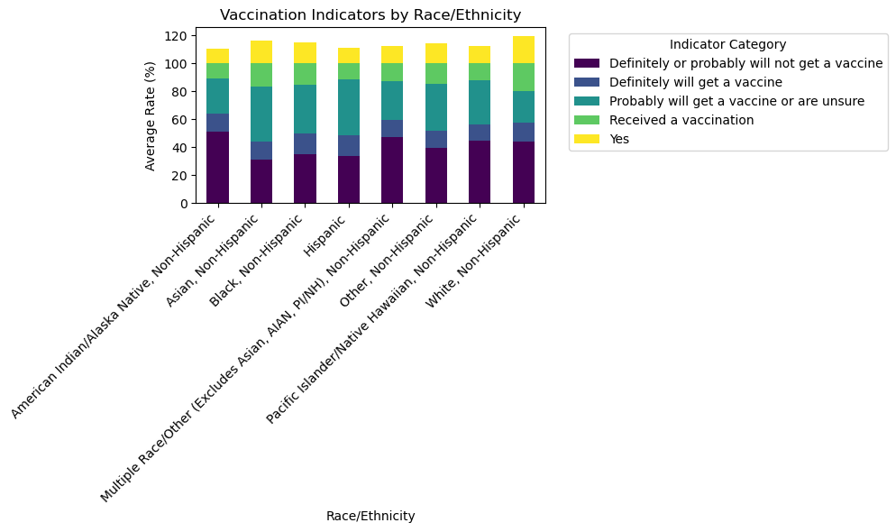

```python
# Filter data for Race/Ethnicity demographics
race_ethnicity_data = data[data['Demographic Level'] == 'Race/Ethnicity']

# Pivot data for stacked bar chart
pivot_data = race_ethnicity_data.pivot_table(
    index='Demographic Name',
    columns='indicator_category_label',
    values='Estimate',
    aggfunc='mean'
)

# Plot stacked bar chart
ax = pivot_data.plot(kind='bar', stacked=True, figsize=(10, 6), colormap='viridis')

# Customize legend
plt.legend(title='Indicator Category', bbox_to_anchor=(1.05, 1), loc='upper left')
plt.title('Vaccination Indicators by Race/Ethnicity')
plt.ylabel('Average Rate (%)')
plt.xlabel('Race/Ethnicity')
plt.xticks(rotation=45, ha='right')

# Adjust layout for better spacing
plt.tight_layout()
plt.show()
```

### Vaccination Rates by Age Group

Information below will address trends over time for various age group. We are primarily assessing the wilingness of different age groups to get vaccinated.

```python
agedf=pd.read_csv('CDC_AgeData.csv')
agedf
```

|  | Demographic Name | indicator_label | indicator_category_label | Month_Week | Week_ending | Estimate |
| --- | --- | --- | --- | --- | --- | --- |
| 0 | 18-49 years | Up-to-date | Yes | October Week 1 | 9/30/23 0:00 | 1.4000 |
| 1 | 18-49 years | 4-level vaccination and intent | Definitely or probably will not get a vaccine | October Week 1 | 9/30/23 0:00 | 43.4000 |
| 2 | 50-64 years | Up-to-date | Yes | October Week 1 | 9/30/23 0:00 | 3.9000 |
| 3 | 50-64 years | 4-level vaccination and intent | Definitely or probably will not get a vaccine | October Week 1 | 9/30/23 0:00 | 34.4000 |
| 4 | 65+ years | Up-to-date | Yes | October Week 1 | 9/30/23 0:00 | 6.1000 |
| ... | ... | ... | ... | ... | ... | ... |
| 459 | 50-64 years | Up-to-date | Yes | November Week 3 | 11/16/24 0:00 | 19.9000 |
| 460 | 65+ years | 4-level vaccination and intent | Definitely or probably will not get a vaccine | November Week 3 | 11/16/24 0:00 | 29.6000 |
| 461 | 65+ years | Up-to-date | Yes | November Week 3 | 11/16/24 0:00 | 41.0000 |
| 462 | 50-64 years | 4-level vaccination and intent | Definitely or probably will not get a vaccine | November Week 3 | 11/16/24 0:00 | 47.0063 |
| 463 | 50-64 years | Up-to-date | Yes | November Week 3 | 11/16/24 0:00 | 19.8891 |

464 rows × 6 columns

```python
agedf.loc[:, 'Week_ending'] = pd.to_datetime(agedf['Week_ending'])
agedf.head()
```

|  | Demographic Name | indicator_label | indicator_category_label | Month_Week | Week_ending | Estimate |
| --- | --- | --- | --- | --- | --- | --- |
| 0 | 18-49 years | Up-to-date | Yes | October Week 1 | 2023-09-30 00:00:00 | 1.4 |
| 1 | 18-49 years | 4-level vaccination and intent | Definitely or probably will not get a vaccine | October Week 1 | 2023-09-30 00:00:00 | 43.4 |
| 2 | 50-64 years | Up-to-date | Yes | October Week 1 | 2023-09-30 00:00:00 | 3.9 |
| 3 | 50-64 years | 4-level vaccination and intent | Definitely or probably will not get a vaccine | October Week 1 | 2023-09-30 00:00:00 | 34.4 |
| 4 | 65+ years | Up-to-date | Yes | October Week 1 | 2023-09-30 00:00:00 | 6.1 |

```python
agedf.loc[:, 'Week_ending'] = pd.to_datetime(agedf['Week_ending'], format='%Y-%m-%d')
```

```python
agedf_grouped = agedf.groupby(
    ['Demographic Name', 'indicator_category_label', 'Week_ending']
)['Estimate'].sum().reset_index()
agedf_grouped
```

|  | Demographic Name | indicator_category_label | Week_ending | Estimate |
| --- | --- | --- | --- | --- |
| 0 | 18-49 years | Definitely or probably will not get a vaccine | 2023-09-30 | 43.4 |
| 1 | 18-49 years | Definitely or probably will not get a vaccine | 2023-10-07 | 42.4 |
| 2 | 18-49 years | Definitely or probably will not get a vaccine | 2023-10-14 | 42.2 |
| 3 | 18-49 years | Definitely or probably will not get a vaccine | 2023-10-21 | 44.8 |
| 4 | 18-49 years | Definitely or probably will not get a vaccine | 2023-10-28 | 47.3 |
| ... | ... | ... | ... | ... |
| 343 | 65+ years | Yes | 2024-10-19 | 28.5 |
| 344 | 65+ years | Yes | 2024-10-26 | 29.9 |
| 345 | 65+ years | Yes | 2024-11-02 | 37.6 |
| 346 | 65+ years | Yes | 2024-11-09 | 39.9 |
| 347 | 65+ years | Yes | 2024-11-16 | 41.0 |

348 rows × 4 columns

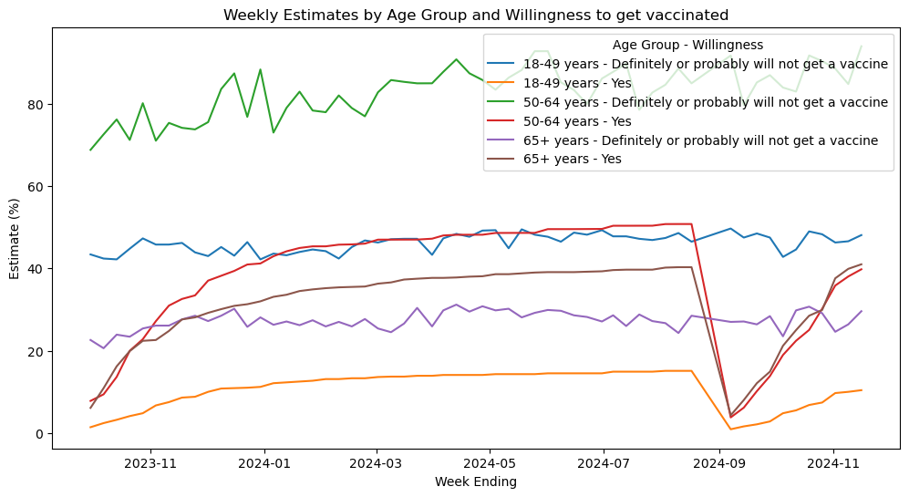

```python
plt.figure(figsize=(12, 6))

for (demographic_name, indicator_category), group_data in agedf_grouped.groupby(['Demographic Name', 'indicator_category_label']):

    plt.plot(group_data['Week_ending'], group_data['Estimate'], label=f'{demographic_name} - {indicator_category}')

plt.title('Weekly Estimates by Age Group and Willingness to get vaccinated')
plt.xlabel('Week Ending')
plt.ylabel('Estimate (%)')
plt.legend(title='Age Group - Willingness')
plt.show()
```

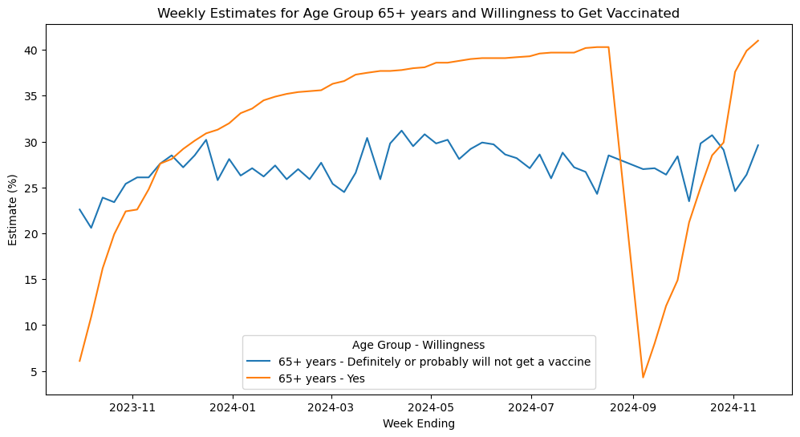

```python
def plot_age_group_data(age_group_to_show):
    age_group_filtered = agedf_grouped[agedf_grouped['Demographic Name'] == age_group_to_show]

    plt.figure(figsize=(12, 6))

    for (demographic_name, indicator_category), group_data in age_group_filtered.groupby(['Demographic Name', 'indicator_category_label']):
        plt.plot(group_data['Week_ending'], group_data['Estimate'], label=f'{demographic_name} - {indicator_category}')

    plt.title(f'Weekly Estimates for Age Group {age_group_to_show} and Willingness to Get Vaccinated')
    plt.xlabel('Week Ending')
    plt.ylabel('Estimate (%)')
    plt.legend(title='Age Group - Willingness')
    plt.show()

#3choices
#plot_age_group_data('18-49 years')
#plot_age_group_data('50-64 years')
plot_age_group_data('65+ years')
```